# Did Trump’s Tone Change During the 2019 Impeachment Inquiry?

Text Analysis Project Showcase · November 3, 2026

Author

Esteban Fernandez · POLS 4130 · Fall 2026

## Question

How did the tone of Donald Trump’s Twitter posts change during the 2019 impeachment inquiry (September–December) compared with the earlier months of the year (January–August)?

### Data

All 4,469 original posts from Trump’s Twitter account between January 1 and December 31, 2019 (retweets excluded). One row is one post. Posts are grouped by month, and the months are combined into two periods: January–August (2,664 posts) and September–December, the impeachment inquiry (1,805 posts).

### Methods

**Sentiment:** I used the Bing Liu dictionary (6,556 words; +1 positive, −1 negative). I summed the matched values within each post to get a net score, then averaged the post scores by month and by period. All 4,469 posts were scored. On average, about 11% of the words in a post matched the dictionary (11.1% in Jan–Aug, 11.6% in Sept–Dec).

**Topics:** I lemmatized words, removed SMART stopwords and numbers, and fit an LDA model (Gibbs sampling, seed 4130) with k = 3. I chose k = 3 because it produced three distinct, readable word groups: endorsements and the border; Democrats and “fake news”; and claims about the country, jobs, and things being “big” and “great.” 4,441 of 4,469 posts kept words for modeling (28 had none). I read the highest-weight posts for each topic before naming it.

## Sentiment finding

Trump’s tone stayed mildly positive during the impeachment inquiry. The average post scored +0.22 in Sept–Dec compared with +0.27 in Jan–Aug, only a small drop. The only negative month was March (−0.13), around the release of the Mueller report, not during impeachment.

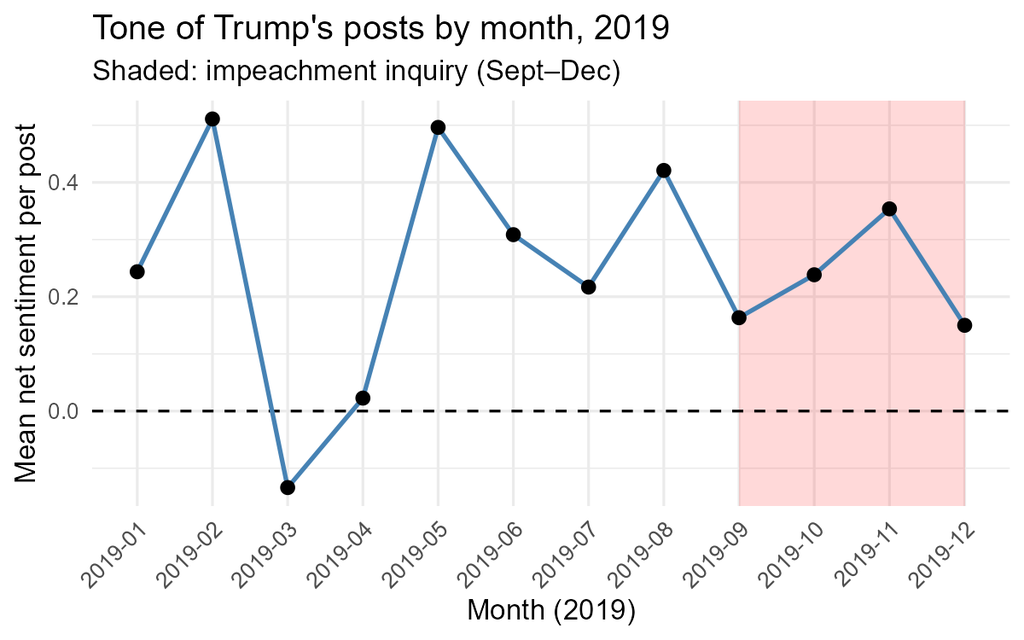

*Mean net Bing Liu score per post for each month of 2019 (4,469 posts). The shaded area marks the impeachment inquiry (Sept–Dec). Points above 0 mean positive words outnumbered negative words on average.*

## Topic finding

Attacks on Democrats and the media grew only slightly during impeachment, rising from 32.8% of the average post in Jan–Aug to 34.3% in Sept–Dec. “Endorsements, border & jobs” (33.5% → 33.0%) and “America-first boasting” (33.7% → 32.7%) each fell by about a point.

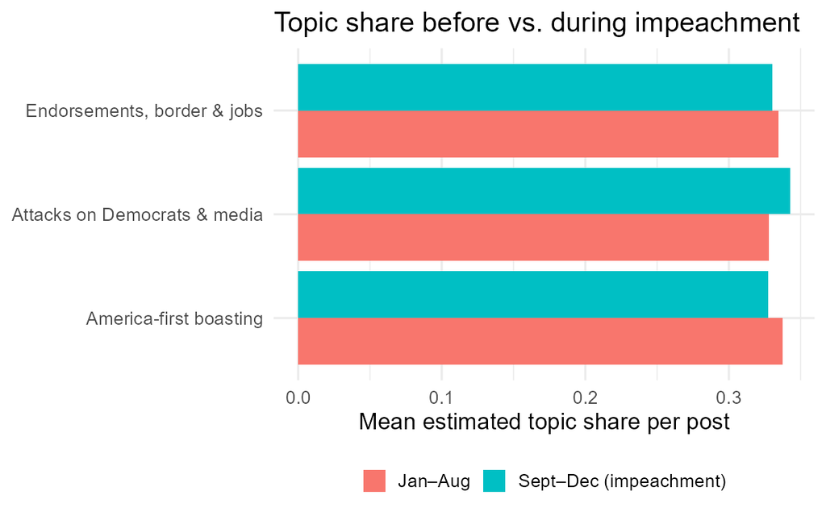

*Average estimated topic share per post in each period, from an LDA model with k = 3 fit to 4,441 posts with retained words. Bars are average proportions, not counts of posts.*

## Check the original texts

**Sentiment:** Post 1 complains that Senator Schumer is holding up “360 great and hardworking people” and scored +1 (“great” +1, “approval” +1, “delayed” −1). The post is an attack, so the positive score misses its meaning. Post 3, “HAPPY NEW YEAR!”, scored +1, which does fit its wording.

**Topics:** “Endorsements, border & jobs” has the keywords great, people, state, border, republican, and job. Its top post (ID 4127) endorses Congressman Lance Gooden as “Strong on Crime and the Border.” An ambiguous example is ID 435, about a “State of Emergency at our Southern Border.” It is not an endorsement but still scores high on this topic, because border and praise words overlap.

### Limits

**Sentiment:** The dictionary counts words, not meaning. Attacks phrased with positive words, like post 1, score as positive, and slogans with “great” add points regardless of context. Posts were also shorter during impeachment (28.9 vs. 32.5 words), which gives fewer chances to match the dictionary.

**Topics:** Many posts mix themes. Post 435 combines border security with praise, so one post can split across topics. The three topics are close to equal in size (about 33% each), and the labels are my own interpretation, which could change with a different k or stopword list.

### Answer to the question

Trump’s tone did not become clearly more negative during the impeachment inquiry. Average sentiment dipped only slightly (+0.27 to +0.22), and attacks on Democrats and the media grew only modestly (32.8% to 34.3%). He kept a mostly positive, self-promoting style while fighting impeachment. This corpus describes only his own posts; it cannot show his intent, how the public reacted, or whether impeachment caused these small changes.

**Sources:** Mark Huang, *Complete Trump Tweets Archive*, https://github.com/MarkHershey/CompleteTrumpTweetsArchive (commit 0de3178). Posts dated January 1–December 31, 2019; retweets, posts with no text, and one duplicate removed, leaving 4,469 original posts. Sentiment dictionary: Hu, M. & Liu, B. (2004), “Mining and Summarizing Customer Reviews,” *KDD 2004*, distributed through tidytext (6,556-word course version).